# Genomic Selection

Jinliang Yang

04-24-2025

# A real world example: Loblolly pine data

In this example, we will use the breeding values of crown width across the planting beds at age 6 (CWAC6).

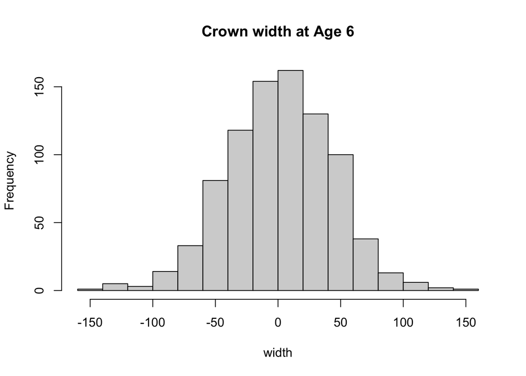

```r
# read phenotype and SNP files
pheno_file <- "https://jyanglab.com/img/data/DATA_nassau_age6_CWAC.csv"
geno_file <- "https://jyanglab.com/img/data/Snp_Data.csv"

pheno <- read.csv(pheno_file, header=TRUE, stringsAsFactors = FALSE)
hist(pheno$Derregressed_BV, main="Crown width at Age 6", xlab="width")
```

```r
# geno[1:10, 1:10]
```

# Loblolly pine data

### Remove missing phenotypes

There are some accessions containing no phenotype. We need to remove these accessions first.

```r
na.index <-  which(is.na(pheno$Derregressed_BV))
# length(na.index)
pheno <- pheno[-na.index, ]

# phenotypes
y <- pheno$Derregressed_BV
y <- matrix(y, ncol=1)
```

# Genotype data: SNP quality control

In the `geno` matrix, row indicates individual, column indicates SNPs.

### Missingness and MAF

```r
geno <- read.csv(geno_file, header=TRUE, stringsAsFactors = FALSE)
dim(geno)
```

```
## [1]  926 4854
```

```r
# Keep genotypes for these remaining lines
geno <- geno[geno$Genotype %in% pheno$Genotype, ]
# markers
geno <- geno[,-1] # 861 x 4853
geno[geno == -9] <- NA

# missing rate
missing <- apply(geno, 2, function(x){sum(is.na(x))/length(x)})
# minor allele frequency
maf <- apply(geno, 2, function(x){
  frq <- mean(x, na.rm=TRUE)/2 # 1 allele
  return(ifelse(frq > 0.5, 1-frq, frq))
})
```

# Genotype data: SNP quality control

In the `geno` matrix, row indicates individual, column indicates SNPs.

#### Plot the results

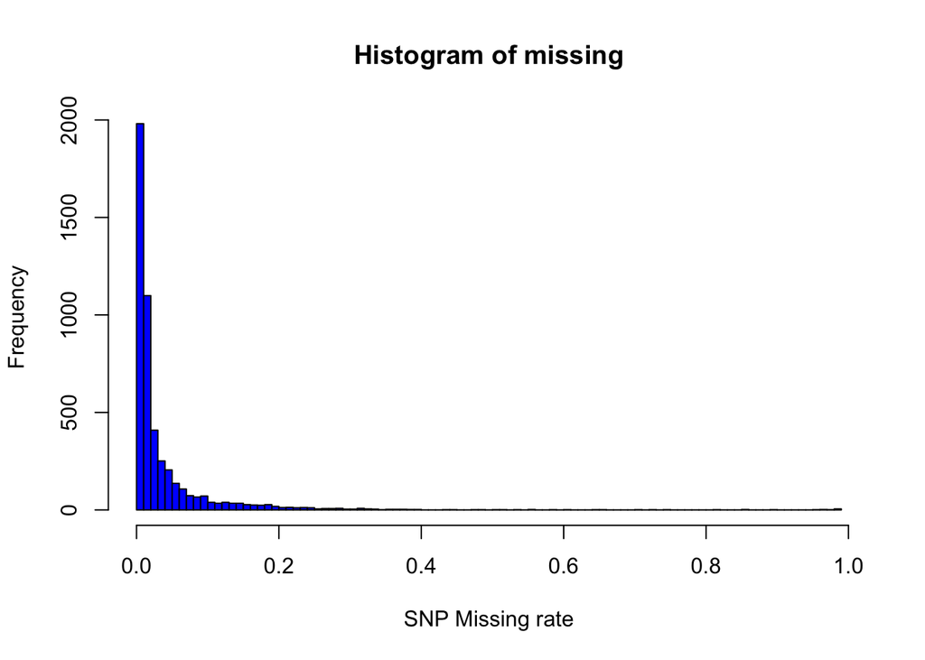

```r
hist(missing, breaks=100, col="blue", xlab="SNP Missing rate")
```

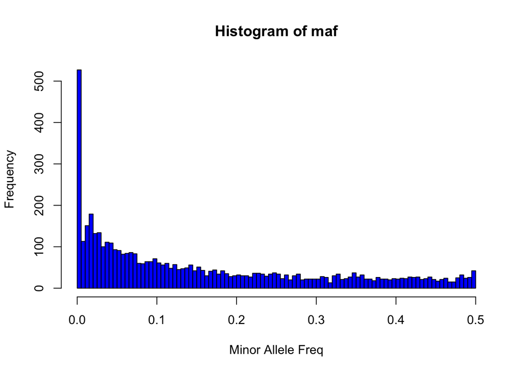

```r
hist(maf, breaks=100, col="blue", xlab="Minor Allele Freq")
```

Removing SNPs with high missing rate (missingness > 0.2) and low MAF (MAF < 0.05)

- Question: How many markers are removed?

```r
idx1 <- which(missing > 0.2) #154
idx2 <- which(maf < 0.05) #1647
idx <- unique(c(idx1, idx2)) #1784

geno2 <- geno[, -idx]
dim(geno2)
```

```
## [1]  861 3069
```

### Missing marker imputation

Replace missing marker genotypes with **mean values**. Then store the marker genotypes in a matrix object `Z`.

```r
Z <- matrix(0, ncol=ncol(geno2), nrow=nrow(geno2))
for (j in 1:ncol(geno2)){
  #cat("j = ", j, '\n')
  Z[,j] <- ifelse(is.na(geno2[,j]), mean(geno2[,j], na.rm=TRUE), geno2[,j])
}
# sum(is.na(Z))
write.table(Z, "data/Z.txt", sep="\t", row.names = FALSE,
            col.names=FALSE, quote=FALSE)
```

# Genomic relationship

### SNP Matrix standardization

Standardize the genotype matrix to have a mean of zero and variance of one. Save this matrix as `Zs`.

```r
Zs <- scale(Z, center = TRUE, scale = TRUE)
# dimensions
n <- nrow(Zs)
m <- ncol(Zs)
```

### Calcualte genomic relationship

- Compute the second genomic relationship matrix of [VanRaden (2008)](https://www.ncbi.nlm.nih.gov/pubmed/18946147) using the entire markers.
- Then add a very small positive constant (e.g., 0.001) to the diagonal elements so that `G` matrix is invertible. A singular matrix cannot be inverted, which poses computational challenges.

```r
# Given matrices x and y as arguments, return a matrix cross-product.
# This is formally equivalent to (but usually slightly faster than)
# the call t(x) %*% y (crossprod) or x %*% t(y) (tcrossprod).
G <- tcrossprod(Zs) / ncol(Zs)
# G <- Zs %*% t(Zs) /ncol(Zs)
G <- G + diag(n)*0.001
```

- `tcrossprod(Zs)` computes the matrix product of Zs and its transpose, yielding an n x n matrix where n is the number of individuals.
- Dividing by the number of markers (ncol(Zs)) standardizes the matrix.

# Solve MME for GBLUP

Set up mixed model equations (MME) by fitting the model:

$$\mathbf{y = 1\mu + Zu + e}$$

- where $\mu$ is the intercept,
- $\mathbf{Z}$ is the incident matrix of individuals,
- $\mathbf{u}$ is the breeding value of the individuals,
- and $\mathbf{e}$ is the residual.

Directly take the inverse of LHS to obtain the solutions for GBLUP. Report the estimates of intercept and additive genetic values. Use $\lambda = 1.35$.

```r
lambda <- 1.35 # fit$Ve / fit$Vg
Ginv <- solve(G)
ones <- matrix(1, ncol=1, nrow=n)
Z <- diag(n)
# Given matrices x and y as arguments, return a matrix cross-product.
#This is formally equivalent to (but usually slightly faster than)
#the call t(x) %*% y (crossprod) or x %*% t(y) (tcrossprod).
LHS1 <- cbind(crossprod(ones), crossprod(ones, Z))
LHS2 <- cbind(crossprod(Z, ones), crossprod(Z) +  Ginv*lambda)
LHS <- rbind(LHS1, LHS2)
RHS <- rbind( crossprod(ones, y), crossprod(Z,y) )
sol <- solve(LHS, RHS)
head(sol)
```

```
##            [,1]
## [1,]   2.275528
## [2,]  12.915583
## [3,] -15.949010
## [4,]  18.411816
## [5,]   4.649033
## [6,] -23.828528
```

```r
tail(sol)
```

```
##              [,1]
## [857,]  -3.877303
## [858,]   5.900186
## [859,]   7.631312
## [860,] -49.125424
## [861,]  -8.490103
## [862,] -37.223103
```

# R package: `rrBLUP`

Fit GBLUP by using the `mixed.solve` function in the [rrBLUP](https://cran.r-project.org/web/packages/rrBLUP/index.html) R package.

- Report the estimates of intercept and additive genetic values.
- Do they agree with previous estimates?
- Also, report the estimated genomic heritability and the ratio of variance components $\lambda = \frac{V_e}{V_A}$.

```r
#install.packages("rrBLUP")
library(rrBLUP)
fit <- mixed.solve(y = y, K=G)
# additive genetic variance
fit$Vu
```

```
## [1] 721.3393
```

```r
# residual variance
fit$Ve
```

```
## [1] 997.0729
```

```r
# intercept
fit$beta
```

```
## [1] 2.275528
```

```r
# additive genetic values
head(fit$u)
```

```
## [1]  12.872001 -16.009856  18.153310   4.307152 -23.873051  16.372003
```

```r
tail(fit$u)
```

```
## [1]  -3.964626   6.047412   7.634191 -48.812717  -8.437586 -36.961484
```

```r
# genomic h2
fit$Vu / (fit$Vu + fit$Ve)
```

```
## [1] 0.4197708
```

```r
# ratio of variance components
fit$Ve / fit$Vu
```

```
## [1] 1.382252
```

```r
# plot(x=sol[-1], y=fit$u)
```

# RR-BLUP

Set up mixed model equations (MME) by fitting the model $\mathbf{y = 1b + Zm + e}$, where $\mathbf{b}$ is the intercept, $\mathbf{Z}$ is the standardized marker genotypes (`Zs`), $\mathbf{m}$ is the additive marker genetic effects, and $\mathbf{e}$ is the residual.

$$\begin{align*}
\begin{bmatrix}
\mathbf{\hat{b}} \\
\mathbf{\hat{m}} \\
\end{bmatrix}
=
\begin{bmatrix}
\mathbf{X^{'}R^{-1}X} & \mathbf{X^{'}R^{-1}Z} \\
\mathbf{Z^{'}R^{-1}X} & \mathbf{Z^{'}R^{-1}Z} +
\mathbf{I} V_e/V_{M_i} \\
\end{bmatrix}^{-1}
\begin{bmatrix}
\mathbf{X^{'}R^{-1}y} \\
\mathbf{Z^{'}R^{-1}y} \\
\end{bmatrix}
\end{align*}$$

Directly take the inverse of LHS to obtain the solutions for marker-based GBLUP (RR-BLUP). Report the estimates of intercept and marker additive genetic effects. Use $\lambda = 4326.212$.

–

```r
lambda <- 4326.212 # fit$Ve / fit$Vu
ones <- matrix(1, ncol=1, nrow=n)
I <- diag(m)
LHS1 <- cbind(crossprod(ones), crossprod(ones, Zs))
LHS2 <- cbind(crossprod(Zs, ones), crossprod(Zs) +  I*lambda)
LHS <- rbind(LHS1, LHS2)
RHS <- rbind( crossprod(ones, y), crossprod(Zs,y) )
sol2 <- solve(LHS, RHS)
head(sol2)
```

```
##             [,1]
## [1,]  2.27552828
## [2,]  0.25984118
## [3,] -0.03032116
## [4,] -0.12452689
## [5,]  0.15758584
## [6,] -0.13104812
```

```r
tail(sol2)
```

```
##                 [,1]
## [3065,]  0.009042828
## [3066,]  0.065547947
## [3067,] -0.235825005
## [3068,]  0.042984822
## [3069,]  0.102930180
## [3070,]  0.262549987
```

# Use `rrBLUP` package

Fit RR-BLUP by using the `mixed.solve` function in the [rrBLUP](https://cran.r-project.org/web/packages/rrBLUP/index.html) R package.

- Report the estimates of intercept and marker additive genetic effects.
- o they agree with the estimates with the manual calculation?
- Also, report the ratio of variance components $\lambda = \frac{V_e}{V_A}$.

```r
library(rrBLUP)
fit2 <- mixed.solve(y = y, Z=Zs)
# marker additive genetic variance
fit2$Vu
```

```
## [1] 0.2350402
```

```r
# residual variance
fit2$Ve
```

```
## [1] 997.7947
```

```r
# intercept
fit2$beta
```

```
## [1] 2.275528
```

```r
# marker additive genetic effects
head(fit2$u)
```

```
## [1]  0.26285584 -0.03075328 -0.12570117  0.16019719 -0.13267752 -0.06454280
```

```r
tail(fit2$u)
```

```
## [1]  0.008232377  0.066259519 -0.237935580  0.042789624  0.103950959
## [6]  0.264838013
```

```r
# ratio of variance components
fit2$Ve / fit2$Vu
```

```
## [1] 4245.208
```

```r
# plot(x=sol2[-1], y=fit2$u)
```

# K-fold validation

Repeat GBLUP but treat the first 600 individuals as a training set and predict the additive genetic values of the remaining individuals in the testing set. - What is the predictive correlation in the testing set? Use $\lambda = 1.348411$.

```r
n.trn <- 600
n.tst <- 261
y.trn <- y[1:n.trn]
y.tst <- y[n.trn+1:n.tst]
Zs.trn <- Zs[1:n.trn,]
Zs.tst <- Zs[n.trn+1:n.tst,]

Gtrn <- tcrossprod(Zs.trn) / ncol(Zs.trn)
Gtrn <- Gtrn + diag(n.trn)*0.001
Gtst.trn <- tcrossprod(Zs.tst, Zs.trn) / ncol(Zs.tst)
#Gtrn <- G[1:n.trn, 1:n.trn]
#Gtst.trn <- G[n.trn+1:n.tst, 1:n.trn]

lambda <- 1.348411 # fit$Ve / fit$Vu
Ginv.trn <- solve(Gtrn)
ones <- matrix(1, ncol=1, nrow=n.trn)
Z <- diag(n.trn)
LHS1 <- cbind(crossprod(ones), crossprod(ones, Z))
LHS2 <- cbind(crossprod(Z, ones), crossprod(Z) +  Ginv.trn*lambda)
LHS <- rbind(LHS1, LHS2)
RHS <- rbind( crossprod(ones, y.trn), crossprod(Z,y.trn) )
sol.trn <- solve(LHS, RHS)

# prediction
y.hat <- Gtst.trn %*% Ginv.trn %*% matrix(sol.trn[c(2:(n.trn+1))])
cor(y.hat, y[(n.trn+1):n])
```

```
##           [,1]
## [1,] 0.4635443
```

```r
# plot(y.hat, y[(n.trn+1):n])
```

```r
Zs.trn <- Zs[1:n.trn, ]
Zs.tst <- Zs[n.trn+1:n.tst, ]
lambda <- 4326.212 # fit$Ve / fit$Vu
ones <- matrix(1, ncol=1, nrow=n.trn)
I <- diag(m)
LHS1 <- cbind(crossprod(ones), crossprod(ones, Zs.trn))
LHS2 <- cbind(crossprod(Zs.trn, ones), crossprod(Zs.trn) +  I*lambda)
LHS <- rbind(LHS1, LHS2)
RHS <- rbind( crossprod(ones, y.trn), crossprod(Zs.trn, y.trn) )
sol.trn <- solve(LHS, RHS)

# prediction
y.hat2 <- Zs.tst %*% matrix(sol.trn[-1])
# cor(y.hat2, y[(n.trn+1):n])
# plot(y.hat2, y[(n.trn+1):n])
```